# Benford’s Law: Session Exercises

Module 1, Day 5 — DATASCI 406, Computational Methods in Statistics and Data Science

Mark M. Fredrickson (mfredric@umich.edu)

**Benford’s Law** says the leading digit of a number — the 2 in 242, the 5 in 5670 — is not uniform on $\{1, \ldots, 9\}$ but follows

$$P(D = d) =
\log_{10}\!\left(\frac{d+1}{d}\right), \qquad d = 1, \ldots,
9,$$

so ones turn up about 30% of the time and nines about 4.6%. It is used in tax auditing and election forensics on the theory that fabricated numbers do not obey it.

# Leading Digits

Let $x$ be any real number with $x \ge 1$ and write:

$$x = 10^{m + f}$$

Where $m$ is the largest integer such that $x \ge 10^m$. Then by construction $m \ge 0$ and $0 \le f < 1$. Splitting $x$ this way separates its **scale** from its **digits**:

$$x = 10^m \cdot 10^f.$$

Because $0 \le f < 1$ we have $1 \le 10^f < 10$, and multiplying by $10^m$ only moves the decimal point. So $10^f$ is the digit string of $x$ with the point placed after the first digit — the **mantissa**. For $242 = 10^2 \cdot 2.42$ it is $2.42$; for $5670 = 10^3 \cdot 5.67$ it is $5.67$. The leading digit is therefore

$$D(x) = \left\lfloor 10^{f}
\right\rfloor, \qquad f = \log_{10}(x) \bmod 1.$$

Due to the finite precision of computers, we have to compute $D(x)$ slightly differently than the ideal form. Rearranging $x = 10^m \cdot 10^f$ gives $10^f = x / 10^m$, so the same digit is equally

$$D(x) = \left\lfloor \frac{x}{10^{m}}
\right\rfloor,
\qquad m = \lfloor \log_{10} x \rfloor.$$

## Exercise 1 — Computing the first digit

Write `first_digit(x)` using the second form. The floor operator is `floor()`.

```r
# solution
```

Check your solution:

```r
first_digit(c(242, 5670, 91000))
first_digit(c(1:9, 80, 900))
```

### Solution

```r
first_digit <- function(x) floor(x / 10^floor(log10(x)))
first_digit(c(242, 5670, 91000))
```

```
#> [1] 2 5 9
```

```r
first_digit(c(1:9, 80, 900))
```

```
#>  [1] 1 2 3 4 5 6 7 8 9 8 9
```

# Distributions over $D$

Notice that many values for $f$ will result in the same first digit because we take the floor of $10^f$. A digit therefore corresponds not to one value of $f$ but to a whole **set** of them — every $f$ with $\lfloor 10^f \rfloor = d$, which is every $f$ satisfying

$$d \; \le \; 10^{f} \; < \; d +
1.$$

The set of $f$ that produce digit $d$ is an **interval**:

$$I_d = \left[\, \log_{10} d, \;
\log_{10}(d+1) \,\right) \qquad d = 1, \ldots, 9$$

A distribution over leading digits is therefore a distribution over the intervals $I_d$. To generate random numbers for this distribution, imagine picking an interval $I_d$, then picking an $F$ within that interval. Select $M$ following some other method and $X = 10^M 10^F$.

## Exercise 2 — Uniform leading digits

Generate 10,000 draws this way: choose one of the nine intervals $I_d$ uniformly, choose $F$ uniformly within it, choose $M \sim \text{Poisson}(2)$, and set $X = 10^{M} 10^{F}$. Plot a histogram of the draws.

### Solution

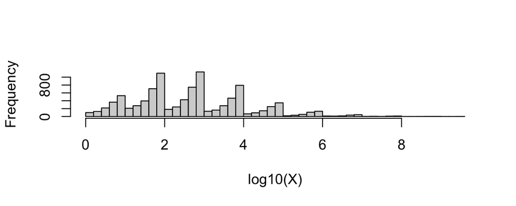

```r
n <- 10000
d <- sample(1:9, n, TRUE)
f <- runif(n, log10(d), log10(d + 1))
x <- 10^(rpois(n, 2) + f)

hist(log10(x), breaks = 40, main = NULL, xlab = "log10(X)")
```

The draws run from 1 to about $3 \times 10^9$, so the histogram is on the log scale. The leading digits are uniform by construction:

```r
round(table(factor(first_digit(x), levels = 1:9)) / n, 3)
```

```
#>
#>     1     2     3     4     5     6     7     8     9
#> 0.109 0.107 0.106 0.115 0.117 0.112 0.111 0.111 0.112
```

# Benford’s Law

The interval $I_d$ for digit $d$ has width

$$w_d = \log_{10}(d+1) - \log_{10} d =
\log_{10}\!\left(\frac{d+1}{d}\right),$$

and these widths are nowhere near equal. Digit 1 owns 30% of the interval (0,1), digit 9 owns 4.6%:

```r
# widths
round(log10((2:10) / (1:9)), 3)
```

```
#> [1] 0.301 0.176 0.125 0.097 0.079 0.067 0.058 0.051 0.046
```

Benford’s Law states that the probability of selecting $F$ to be in $I_d$ is equal to $w_d$. A sufficient condition to be true is when $F$ is uniform on (0,1)

## Exercise 3 — Benford leading digits

Repeat the previous exercise using $F \sim U(0,1)$

### Solution

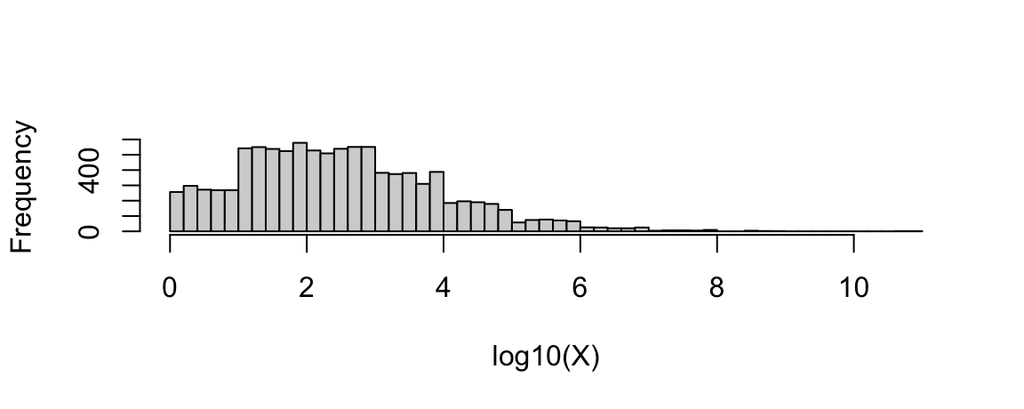

```r
n <- 10000
x <- 10^(rpois(n, 2) + runif(n))

hist(log10(x), breaks = 40, main = NULL, xlab = "log10(X)")
```

```r
round(table(factor(first_digit(x), levels = 1:9)) / n, 3)
```

```
#>
#>     1     2     3     4     5     6     7     8     9
#> 0.300 0.179 0.126 0.095 0.075 0.067 0.060 0.048 0.049
```

No interval is chosen now, and the digits come out at $w_d$.

# Real World Benford

So why would we expect the distribution over the intervals $I_d$ to be equal to their widths, or that $F$ was uniform on $(0,1)$?

Recall the Central Limit Theorem states that for IID variables $Y_i$ with mean $\mu$ and variance $\sigma^2$, $\sum_{i=1}^k Y_i \approx N(k \mu, k \sigma^2)$. In this particular case, suppose that $\mu > 0$. Write $V = 10^Y$, so that $\sum_{i=1}^k \log_{10} V_i \approx N(k \mu, k \sigma^2)$.

Split that sum into its integer and fractional parts, $\sum_{i=1}^k \log_{10} V_i = M + F$, as we did in the last section. When $k$ is large, the mean of $M + F$ will be $k \mu$, far from zero, and the variance $k \sigma^2$ will imply a very flat distribution over many units. With enough spread $F$ becomes uniform on $(0,1)$, and $P(F \in I_d) \approx w_d$.

Now reverse this logic: $10^{M+F} = 10^{\sum_i \log_{10} V_i}.$ Recall, a sum of logs is the log of a product:
$$10^{\sum_i \log_{10} V_i} =
10^{\log_{10} \prod_i V_i} = \prod_i V_i$$
Writing $X = \prod_{i=1}^k V_i$ we can see that any quantity built by multiplying many IID factors together has Benford leading digits.

## Exercise 4 — Products of $k$ factors

Let $Y_i \sim \text{Exp}(10)$, so every $V_i = 10^{Y_i}$ is at least 1, and let $X = \prod_{i=1}^k V_i$. For $k \in \{1, 5, 25, 100\}$ simulate 100,000 values of $X$, plot the distribution of $F = \log_{10} X \bmod 1$,and tabulate the leading digits against $w_d$.

How large does $k$ have to be?

### Solution

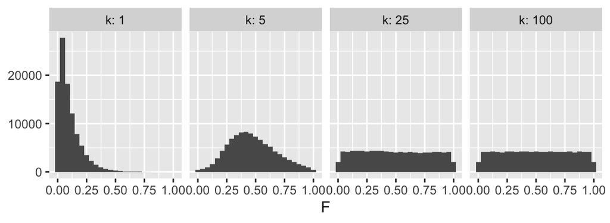

```r
n <- 100000
ks <- c(1, 5, 25, 100)

# generate samples of x of size n for each k
x_n <- map(ks, function(k) replicate(n, {
  y <- rexp(k, 10)
  v <- 10^y
  prod(v)
}))

f_n <- map(x_n, ~ log10(.x) %% 1)

tibble(k = rep(ks, each = n), F = unlist(f_n)) |>
  ggplot(aes(x = F)) + geom_histogram(bins = 25) +
  facet_wrap(~ k, nrow = 1, labeller = label_both) + labs(y = NULL)
```

```r
props <- function(s) {
  set_names(as.numeric(table(factor(first_digit(s), levels = 1:9))) / n, 1:9)
}

tab <- map_dfr(x_n, props) |>
  bind_rows(set_names(log10((2:10) / (1:9)), 1:9)) |>
  mutate(k = c(paste0("k = ", ks), "w_d"), .before = 1)

knitr::kable(tab, digits = 3)
```

| k | 1 | 2 | 3 | 4 | 5 | 6 | 7 | 8 | 9 |
| --- | --- | --- | --- | --- | --- | --- | --- | --- | --- |
| k = 1 | 0.951 | 0.041 | 0.006 | 0.002 | 0.001 | 0.000 | 0.000 | 0.000 | 0.000 |
| k = 5 | 0.212 | 0.336 | 0.198 | 0.109 | 0.061 | 0.037 | 0.023 | 0.015 | 0.010 |
| k = 25 | 0.309 | 0.180 | 0.122 | 0.094 | 0.076 | 0.065 | 0.057 | 0.051 | 0.046 |
| k = 100 | 0.301 | 0.177 | 0.125 | 0.098 | 0.079 | 0.066 | 0.058 | 0.051 | 0.046 |
| w_d | 0.301 | 0.176 | 0.125 | 0.097 | 0.079 | 0.067 | 0.058 | 0.051 | 0.046 |

At $k = 1$ almost everything starts with a 1 and $F$ is nowhere near flat. By $k = 25$ the histogram of $F$ looks level and the digits are close to $w_d$ — though digit 1 is still 0.309 against 0.301, an excess of about five Monte Carlo standard errors at $n = 100{,}000$, so the approximation has not quite arrived. At $k = 100$ they agree to within 0.001, about one standard error.

The standard deviation of $\sum_i \log_{10} V_i$ is $\sqrt{k}/10$, since $\text{Exp}(10)$ has standard deviation $0.1$. So $k = 25$ is half a decade of spread and $k = 100$ is a full decade — that is the answer to how large $k$ has to be.

# A test on real data

Tam Cho and Gaines report leading-digit frequencies for **8,396 contributions between political committees**, from 2004 FEC filings (their Table 1):

```r
pol_digits <- c(23.3, 21.1, 8.5, 11.7, 9.5, 4.2, 3.7, 4.0, 14.1) / 100
```

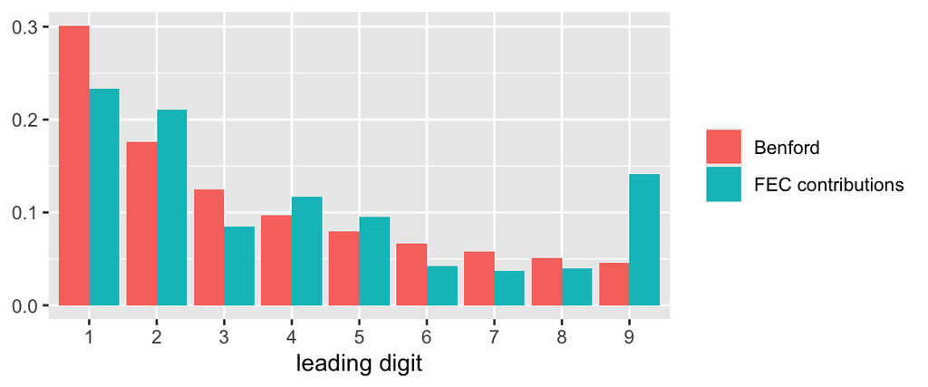

They disagree, most visibly at 9: 14.1% against an expected 4.6%. Is that surprising, or is it what random data looks like?

Instead of $\chi^2$, use the Euclidean distance between the observed and expected digit distributions,

$$T = \sqrt{\sum_d \left(\hat p_d -
p_d\right)^2}.$$

We write it $T$ because it is going to be a test statistic — and because $m$ is already taken, by the integer exponent in the opening derivation.

This is the paper’s own statistic. Tam Cho and Gaines report it divided by the largest distance attainable — all mass on digit 9, which gives 1.036 — and call that $d^*$. So the 0.131 in their Table 1 for 2004 is the $T$ you are about to compute, rescaled. They chose a distance precisely *because* it is not tied to a hypothesis test and does not move with sample size; Exercises 6 and 7 then build a $p$-value and a power curve on it.

These do the bookkeeping. The only piece left to write is `distance()`.

```r
dbenford <- function(d) log10((d + 1) / d)
digit_props <- function(d) as.numeric(table(factor(d, levels = 1:9))) / length(d)
rbenford <- function(n) sample(1:9, n, prob = dbenford(1:9), replace = TRUE)
tstat <- function(d) distance(digit_props(d))
```

## Exercise 5 — The observed statistic

Write `distance(v)`, taking nine proportions and returning $T$. Compute the observed value for `pol_digits`.

### Solution

```r
distance <- function(v) sqrt(sum((v - dbenford(1:9))^2))
(observed <- distance(pol_digits))
```

```
#> [1] 0.1354775
```

## Exercise 6 — The null distribution and the $p$-value

Under $H_0$ the 8,396 digits are iid draws from the Benford distribution. Simulate the null with `B = 4000` replicates, plot it with the observed value marked, and compute the $p$-value with the $(1 + \#)/(B+1)$ formula.

A classmate reports “$p = 0$, so the data cannot be Benford.” What is wrong with that, and what should be reported instead?

### Solution

```r
B <- 4000
null <- replicate(B, tstat(rbenford(8396)))

c(mean = mean(null), max = max(null), observed = observed)
```

```
#>        mean         max    observed
#> 0.009596296 0.022584243 0.135477534
```

```r
(1 + sum(null >= observed)) / (B + 1)
```

```
#> [1] 0.0002499375
```

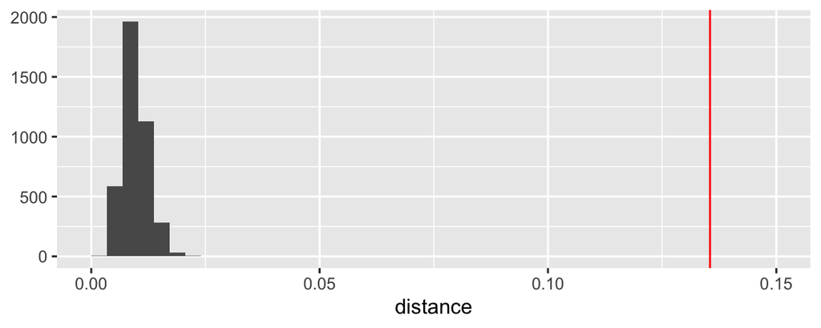

```r
ggplot(tibble(stat = null), aes(x = stat)) + geom_histogram(bins = 40) +
  geom_vline(xintercept = observed, colour = "red") +
  coord_cartesian(xlim = c(0, 0.15)) + labs(x = "distance", y = NULL)
```

No null draw came close, so the formula returns $1/4001 \approx 0.00025$.

A Monte Carlo $p$-value has a resolution floor of about $1/B$: 0.00025 is the smallest value $B = 4000$ can return, whatever the data. Report $p < 0.00025$ and state $B$. A smaller number takes a larger $B$, not different data.

## Exercise 7 — Power against a flatter alternative

Suppose the truth is not Benford but something more uniform — halfway between the two:

```r
p_alt <- 0.5 * dbenford(1:9) + 0.5 / 9
round(p_alt, 3)
```

```
#> [1] 0.206 0.144 0.118 0.104 0.095 0.089 0.085 0.081 0.078
```

For each $n \in \{50, 200, 8396\}$: simulate 1,000 null statistics at that $n$, take the 95% quantile as the critical value, simulate 1,000 more with digits drawn from `p_alt`, and report the fraction above the cutoff. That fraction is the power against this alternative.

What does the $n = 50$ row say about a Benford test run on a small dataset?

### Solution

```r
power_at <- function(n, reps = 1000) {
  crit <- quantile(replicate(reps, tstat(rbenford(n))), 0.95)
  alt <- replicate(reps, tstat(sample(1:9, n, TRUE, prob = p_alt)))
  c(critical = unname(crit), power = mean(alt > crit))
}

ns <- c(50, 200, 8396)
cbind(n = ns, t(sapply(ns, power_at))) |> knitr::kable(digits = 3)
```

| n | critical | power |
| --- | --- | --- |
| 50 | 0.181 | 0.379 |
| 200 | 0.092 | 0.940 |
| 8396 | 0.015 | 1.000 |